# Lab Assignment Six: Convolutional Network Architectures

Team members: Long Zhang,Qinyu Chen, Zhengwen Zhang

## Business understanding

Pollination by bees play a significant role in the food industry, honey production is directly affected by the health condition of hives.We have seen over 60% reduction in honeybee hive losses in some states in the US. the question is: how to predict honey production based on hive health status? can we take actions to prevent the bad hives from getting worse? since the hive abnormalities is invisible from outside, we have to mannually check the hives to get a better understanding of the hive status, however, this invasive method is very labor intensive. Alternatively, we can monitor tell from the phenotypes of bees traveling back and forth, and correlate some characteristics of bees to hive health status.

In this lab, we are using bees image dataset from Kaggle, the bees images have different characteristics, for example, bees with varroa mites infection has been correlated with unhealthy hives. some bees may have damaged body parts(e.g., wings, legs), there are bees that carry pollen, the large influx of bees without pollen could be robber bees. The goal of this study is to predict the bees heath status by evaluating convolutional network architectures. We choose this dataset because it has a large dataset(~5k) for building convolutional network. It has a few different categorical features for the creation of the embeddings and cross-product embeddings.This model will be useful for farmers, expecially for those who have experienced consistant loss in honey production.They can place camera in front of the hives to capture bees flying in and out, screenshots will be taken, and individual bees images will be extracted and used for CCN analysis.By running our model, we will be able to help predict the health status of hives.

data source: https://www.kaggle.com/jenny18/honey-bee-annotated-images

## 1. Preparation

#### 1.1 Choose and explain what metric(s) you will use to evaluate your algorithm’s performance. You should give a detailed argument for why this (these) metric(s) are appropriate on your data. That is, why is the metric appropriate for the task (e.g., in terms of the business case for the task). Please note: rarely is accuracy the best evaluation metric to use. Think deeply about an appropriate measure of performance.

```python
# Common libs
import pandas as pd
import numpy as np
import sys
import os
import random
from pathlib import Path

# Image processing
import imageio
import skimage
import skimage.io
import skimage.transform
#from skimage.transform import rescale, resize, downscale_local_mean

# Charts
import matplotlib.pyplot as plt
import seaborn as sns


# ML
import scipy
from sklearn.model_selection import train_test_split
from sklearn import metrics

#from sklearn.preprocessing import OneHotEncoder
from keras import optimizers
from keras.models import Sequential
from keras.layers import Dense, Conv2D, Flatten, MaxPool2D, Dropout, BatchNormalization,LeakyReLU
from keras.preprocessing.image import ImageDataGenerator
from keras.callbacks import ModelCheckpoint, Callback, EarlyStopping, ReduceLROnPlateau
from keras.utils import to_categorical
import tensorflow

#warning
import warnings
warnings.filterwarnings('ignore')
```

```python
bees = pd.read_csv(r"C:\Users\chenq\Desktop\honey-bee-annotated-images\bee_data.csv")
#bees = pd.read_csv('/Users/terrence/Desktop/bee_data.csv')
df= bees.copy()
bees.head()
```

|  | file | date | time | location | zip code | subspecies | health | pollen_carrying | caste |
| --- | --- | --- | --- | --- | --- | --- | --- | --- | --- |
| 0 | 041_066.png | 8/28/18 | 16:07 | Alvin, TX, USA | 77511 | -1 | hive being robbed | False | worker |
| 1 | 041_072.png | 8/28/18 | 16:07 | Alvin, TX, USA | 77511 | -1 | hive being robbed | False | worker |
| 2 | 041_073.png | 8/28/18 | 16:07 | Alvin, TX, USA | 77511 | -1 | hive being robbed | False | worker |
| 3 | 041_067.png | 8/28/18 | 16:07 | Alvin, TX, USA | 77511 | -1 | hive being robbed | False | worker |
| 4 | 041_059.png | 8/28/18 | 16:07 | Alvin, TX, USA | 77511 | -1 | hive being robbed | False | worker |

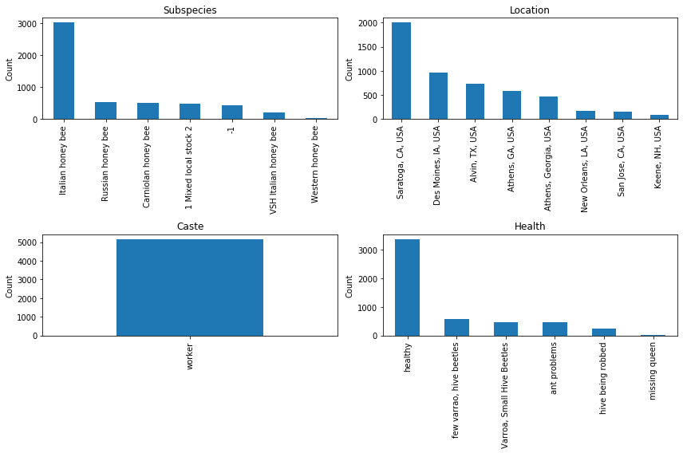

```python
f, ax = plt.subplots(nrows=2, ncols=2, figsize=(12,8))

bees.subspecies.value_counts().plot(kind='bar',ax=ax[0, 0])
ax[0,0].set_ylabel('Count')
ax[0,0].set_title('Subspecies')

bees.location.value_counts().plot(kind='bar', ax=ax[0, 1])
ax[0,1].set_title('Location')
ax[0,1].set_ylabel('Count')

bees.caste.value_counts().plot(kind='bar', ax=ax[1, 0])
ax[1,0].set_title('Caste')
ax[1,0].set_ylabel('Count')

bees.health.value_counts().plot(kind='bar', ax=ax[1,1])
ax[1,1].set_title('Health')
ax[1,1].set_ylabel('Count')

f.subplots_adjust(hspace=0.7)
f.tight_layout()
plt.show()
```

"Health" is the our target. From the plot, the number of heathy group is much higher than other five groups. Data is not balanced, so accuracy is not suitable for us. We choose F1 to evaluate our algorithm's performance.We used 'F1-score' as our evaluation metrics. Aslo,the reason why we selected this metric is F1-score represents test's accuracy, it considers both precision and recall. it takes both false positive and false negative into considerations. it is more useful than accruacy, since our image dataset has uneven class distribution.

```python
from keras import backend as K

def f1(y_true, y_pred):
    def recall(y_true, y_pred):
        """Recall metric.

        Only computes a batch-wise average of recall.

        Computes the recall, a metric for multi-label classification of
        how many relevant items are selected.
        """
        true_positives = K.sum(K.round(K.clip(y_true * y_pred, 0, 1)))
        possible_positives = K.sum(K.round(K.clip(y_true, 0, 1)))
        recall = true_positives / (possible_positives + K.epsilon())
        return recall

    def precision(y_true, y_pred):
        """Precision metric.

        Only computes a batch-wise average of precision.

        Computes the precision, a metric for multi-label classification of
        how many selected items are relevant.
        """
        true_positives = K.sum(K.round(K.clip(y_true * y_pred, 0, 1)))
        predicted_positives = K.sum(K.round(K.clip(y_pred, 0, 1)))
        precision = true_positives / (predicted_positives + K.epsilon())
        return precision
    precision = precision(y_true, y_pred)
    recall = recall(y_true, y_pred)
    return 2*((precision*recall)/(precision+recall+K.epsilon()))
```

#### 1.2 Choose the method you will use for dividing your data into training and testing (i.e., are you using Stratified 10-fold cross validation? Shuffle splits? Why?). Explain why your chosen method is appropriate or use more than one method as appropriate. Convince me that your cross validation method is a realistic mirroring of how an algorithm would be used in practice.

```python
df.info()
```

```
<class 'pandas.core.frame.DataFrame'>
RangeIndex: 5172 entries, 0 to 5171
Data columns (total 9 columns):
 #   Column           Non-Null Count  Dtype
---  ------           --------------  -----
 0   file             5172 non-null   object
 1   date             5172 non-null   object
 2   time             5172 non-null   object
 3   location         5172 non-null   object
 4   zip code         5172 non-null   int64
 5   subspecies       5172 non-null   object
 6   health           5172 non-null   object
 7   pollen_carrying  5172 non-null   bool
 8   caste            5172 non-null   object
dtypes: bool(1), int64(1), object(7)
memory usage: 328.4+ KB
```

Our dataset only have 5172 images,which means our df don't have very large data. Also, our target[Health] is not balanced.From the plot, the number of heathy group is much higher than other five groups.we should do cross validation. First,we split original data into 80% training data and 20% testing data.Then we use Stratified 10-fold cross validation.

Why we use training and testing? Sometimes model can be overfitting or underfitting, so we can split our data to avoid our model overfitting or underfitting.

Why we need 10 fold cross validation?  
1)Use All Data  
2)Get More Metrics,for our model is to get more f1 value.  
3)Use Models Stacking.  
4)Work with Dependent/Grouped Data.  
5)Parameters Fine-Tuning.

```python
#recolor images in order to get our conclusion more clear
# according to class sides,gray = 0.3 * r + 0.59 * g + 0.11 * b
def gray(rgb):
    r, g, b = rgb[:,:,0], rgb[:,:,1], rgb[:,:,2]
    gray = 0.3 * r + 0.59 * g + 0.11 * b
    return gray
```

```python
import glob
from PIL import Image

# transfet image to numpy array
x_data =[]
image_array =[]
image_target =[]

for im_path in glob.glob(r"C:\Users\chenq\Desktop\honey-bee-annotated-images\bee_imgs\bee_imgs\*.png"):
#for im_path in glob.glob("/Users/terrence/Desktop/bee_imgs/bee_imgs/*.png"):
#for im_path in glob.glob(r"C:\Users\tony\Dropbox\smu\CSE7324\assignment\LabTwo\Lab2_shared\honey-bee-annotated-images\bee_imgs\bee_imgs\*.png"):#tony
    # read the images from our members laptop path
    images = Image.open(im_path)
    images = images.resize((78, 78),Image.ANTIALIAS)
    images = gray(np.array(images))
    x_data.append(images)
    image_array.append(np.array(images)/255)
    target =bees[bees.file == im_path.split('\\')[-1]].health.tolist() # using regex to get the name of each image
    #target =bee[bee.file == im_path.split('\\')[-1]].health.tolist() # using regex to get the name of each image
    image_target.append(target)
```

```python
#using two for loops to "extend" and "append" row after row for each image
oneDim_arr = []
for img in image_array:
    each_img =[]
    for row in img:
        each_img.extend(row)
    oneDim_arr.append(each_img)
#print(oneDim_arr[0])
```

```python
#convert them into numpy arrays
X = np.array(oneDim_arr)
y = image_target
```

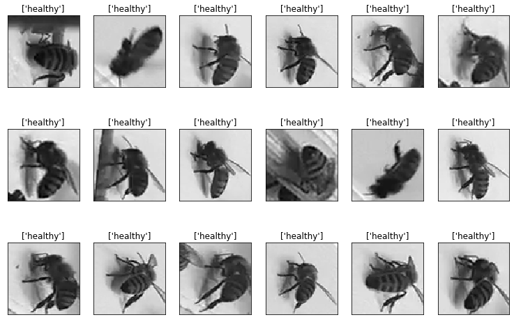

```python
# because the array of size is 6084, it should be resize into 78*78
h = 78
w = 78
def plot_gallery(images, titles, h, w, n_row=3, n_col=6):
    """Helper function to plot a gallery of portraits"""
    plt.figure(figsize=(1.7 * n_col, 2.3 * n_row))
    plt.subplots_adjust(bottom=0, left=.01, right=.99, top=.90, hspace=.35)
    for i in range(n_row * n_col):
        plt.subplot(n_row, n_col, i + 1)
        plt.imshow(images[i].reshape((h, w)), cmap=plt.cm.gray)
        plt.title(titles[i], size=12)
        plt.xticks(())
        plt.yticks(())
#plot some "healthy" bees in gray scale
plot_gallery(X, y, h, w)
```

```python
import keras
from keras.models import Sequential
from keras.layers import Reshape
from keras.layers import Dense, Dropout, Activation, Flatten
from keras.layers import Conv2D, MaxPooling2D
from keras.preprocessing.image import ImageDataGenerator
from keras.callbacks import EarlyStopping
from keras.regularizers import l2
from keras.layers import average
from keras.models import Input, Model

keras.__version__
```

```
'2.3.1'
```

```python
df['health'].unique()
```

```
array(['hive being robbed', 'healthy', 'few varrao, hive beetles',
       'ant problems', 'missing queen', 'Varroa, Small Hive Beetles'],
      dtype=object)
```

```python
classes =['hive being robbed', 'healthy', 'few varrao, hive beetles',
          'ant problems', 'missing queen', 'Varroa, Small Hive Beetles']
img_wh = 78
NUM_CLASSES = len(classes)
```

0:healthy 1:hive being robbed 2:few varrao, hive beetles 3:ant problems 4:missing queen 5:Varroa, Small Hive Beetles

```python
for n, i in enumerate(y):
    if i == ['healthy']:
        y[n]=0
```

```python
for n, i in enumerate(y):
    if i == ['hive being robbed']:
        y[n]=1
```

```python
for n, i in enumerate(y):
    if i == ['few varrao, hive beetles']:
        y[n]=2
```

```python
for n, i in enumerate(y):
    if i == ['ant problems']:
        y[n]=3
```

```python
for n, i in enumerate(y):
    if i == ['missing queen']:
        y[n]=4
```

```python
for n, i in enumerate(y):
    if i == ['Varroa, Small Hive Beetles']:
        y[n]=5
```

```python
from sklearn.model_selection import train_test_split
from sklearn import preprocessing

X_train, X_test, y_train, y_test = train_test_split(X, y, test_size=0.2, stratify=y)

X_train = preprocessing.normalize(X_train)
X_test = preprocessing.normalize(X_test)

# NEW: Let's start by fixing the sizes
X_train = np.expand_dims(X_train.reshape((-1,h,w)), axis=3)
X_test = np.expand_dims(X_test.reshape((-1,h,w)), axis=3)
# the image data has been resized to (samples,image_rows,image_cols,image_channels)

# and one hot encoding the output values
y_train_ohe = keras.utils.to_categorical(y_train, NUM_CLASSES)
y_test_ohe = keras.utils.to_categorical(y_test, NUM_CLASSES)
# y_train_ohe = pd.get_dummies(y_train, drop_first=False)
# y_test_ohe = pd.get_dummies(y_test, drop_first=False)


print(X_train.shape)
print(X_test.shape)
```

```
(4137, 78, 78, 1)
(1035, 78, 78, 1)
```

make one hot code for our target and split data into 80% trainning and 20% testing.

```python
print(y_train_ohe.shape)
print(y_test_ohe.shape)
```

```
(4137, 6)
(1035, 6)
```

## 2. Modeling

2.1 Create a convolutional neural network to use on your data using Keras. Setup the training to use data expansion in Keras. Explain why the chosen data expansion techniques are appropriate for your dataset.

### Data expansion

```python
datagen = ImageDataGenerator(featurewise_center=False,
    samplewise_center=False,
    featurewise_std_normalization=False,
    samplewise_std_normalization=False,
    zca_whitening=False,
    rotation_range=5, # used, Int. Degree range for random rotations.
    width_shift_range=0.1, # used, Float (fraction of total width). Range for random horizontal shifts.
    height_shift_range=0.1, # used,  Float (fraction of total height). Range for random vertical shifts.
    shear_range=0., # Float. Shear Intensity (Shear angle in counter-clockwise direction as radians)
    zoom_range=0.,
    channel_shift_range=0.,
    fill_mode='nearest',
    cval=0.,
    horizontal_flip=True,
    vertical_flip=False,
    rescale=None)

datagen.fit(X_train)
```

Why data expansion is appropriate for our dataset? Since the images are about varieties of bees from different place, it is necessary to change the rotation, width and height shift. We keep shear, zoom, channed_shift range as 0, because we do not need to do shear, zoom and chnned_shift.

```python
%%time

cnn = Sequential()

# let's start with an AlexNet style convolutional phase
cnn.add(Conv2D(filters=32,
                input_shape = (img_wh,img_wh,1),
                kernel_size=(3,3),
                padding='same',
                activation='relu', data_format="channels_last")) # more compact syntax

# no max pool before next conv layer!!
cnn.add(Conv2D(filters=64,
                kernel_size=(3,3),
                padding='same',
                activation='relu')) # more compact syntax
cnn.add(MaxPooling2D(pool_size=(2, 2), data_format="channels_last"))


# add one layer on flattened output
cnn.add(Dropout(0.25)) # add some dropout for regularization after conv layers
cnn.add(Flatten())
cnn.add(Dense(128, activation='relu'))
cnn.add(Dropout(0.5)) # add some dropout for regularization, again!
cnn.add(Dense(NUM_CLASSES, activation='softmax'))
cnn.summary()
```

```
WARNING:tensorflow:From C:\Users\chenq\anaconda3\lib\site-packages\keras\backend\tensorflow_backend.py:4070: The name tf.nn.max_pool is deprecated. Please use tf.nn.max_pool2d instead.

Model: "sequential_1"
_________________________________________________________________
Layer (type)                 Output Shape              Param #
=================================================================
conv2d_1 (Conv2D)            (None, 78, 78, 32)        320
_________________________________________________________________
conv2d_2 (Conv2D)            (None, 78, 78, 64)        18496
_________________________________________________________________
max_pooling2d_1 (MaxPooling2 (None, 39, 39, 64)        0
_________________________________________________________________
dropout_1 (Dropout)          (None, 39, 39, 64)        0
_________________________________________________________________
flatten_1 (Flatten)          (None, 97344)             0
_________________________________________________________________
dense_1 (Dense)              (None, 128)               12460160
_________________________________________________________________
dropout_2 (Dropout)          (None, 128)               0
_________________________________________________________________
dense_2 (Dense)              (None, 6)                 774
=================================================================
Total params: 12,479,750
Trainable params: 12,479,750
Non-trainable params: 0
_________________________________________________________________
Wall time: 116 ms
```

```python
# Let's train the model
cnn.compile(loss='categorical_crossentropy', # 'categorical_crossentropy' 'mean_squared_error'
              optimizer='rmsprop', # 'adadelta' 'rmsprop'
              metrics=[f1])
```

```python
# the flow method yields batches of images indefinitely, with the given transformations
cnn.fit_generator(datagen.flow(X_train, y_train_ohe, batch_size=128),
                   steps_per_epoch=int(len(X_train)/128), # how many generators to go through per epoch
                   epochs=30, verbose=1,
                   validation_data=(X_test,y_test_ohe)
                  )
```

[output not shown]

```
<keras.callbacks.callbacks.History at 0x203302e6888>
```

#### 2.2 Investigate at least two different convolutional network architectures (and investigate changing some parameters of each architecture). Use the method of cross validation and evaluation metric that you argued for at the beginning of the lab. Visualize the performance of the training and validation sets per iteration (use the "history" parameter of Keras).

Because our model needs several hours to run, for adjustment of parameter of each architecture, we only choose Resnet architecture model to do that.

Here, we investigated 4 models: typical CNN, Resnet, Resnet_modify,Xception_model.

## Typical CNN

```python
from keras.callbacks import EarlyStopping
from keras.regularizers import l2
l2_lambda = 0.0001

# Use Kaiming He to regularize ReLU layers: https://arxiv.org/pdf/1502.01852.pdf
# Use Glorot/Bengio for linear/sigmoid/softmax: http://proceedings.mlr.press/v9/glorot10a/glorot10a.pdf
cnn = Sequential()

cnn.add(Conv2D(filters=32,
               input_shape = (img_wh,img_wh,1),
               kernel_size=(3,3),
               kernel_initializer='he_uniform',
               kernel_regularizer=l2(l2_lambda),
               padding='same',
               activation='relu',
               data_format="channels_last")) # more compact syntax

cnn.add(Conv2D(filters=32,
               kernel_size=(3,3),
               kernel_initializer='he_uniform',
               kernel_regularizer=l2(l2_lambda),
               padding='same',
               activation='relu',data_format="channels_last"))
cnn.add(MaxPooling2D(pool_size=(2, 2), data_format="channels_last"))

cnn.add(Conv2D(filters=64,
               input_shape = (img_wh,img_wh,1),
               kernel_size=(3,3),
               kernel_initializer='he_uniform',
               kernel_regularizer=l2(l2_lambda),
               padding='same',
               activation='relu',data_format="channels_last")) # more compact syntax

cnn.add(Conv2D(filters=64,
               kernel_size=(3,3),
               kernel_initializer='he_uniform',
               kernel_regularizer=l2(l2_lambda),
               padding='same',
               activation='relu'))
cnn.add(MaxPooling2D(pool_size=(2, 2), data_format="channels_last"))

cnn.add(Conv2D(filters=128,
               input_shape = (img_wh,img_wh,1),
               kernel_size=(3,3),
               kernel_initializer='he_uniform',
               kernel_regularizer=l2(l2_lambda),
               padding='same',
               activation='relu',data_format="channels_last")) # more compact syntax

cnn.add(Conv2D(filters=128,
               kernel_size=(3,3),
               kernel_initializer='he_uniform',
               kernel_regularizer=l2(l2_lambda),
               padding='same',
               activation='relu',data_format="channels_last"))


# add one layer on flattened output

cnn.add(Flatten())
cnn.add(Dropout(0.25)) # add some dropout for regularization after conv layers
cnn.add(Dense(128,
              activation='relu',
              kernel_initializer='he_uniform',
              kernel_regularizer=l2(l2_lambda)
       ))
cnn.add(Dropout(0.5)) # add some dropout for regularization, again!
cnn.add(Dense(NUM_CLASSES,
              activation='softmax',
              kernel_initializer='glorot_uniform',
              kernel_regularizer=l2(l2_lambda)
             ))

# Let's train the model
cnn.compile(loss='categorical_crossentropy', # 'categorical_crossentropy' 'mean_squared_error'
              optimizer='rmsprop', # 'adadelta' 'rmsprop'
              metrics=[f1])

# the flow method yields batches of images indefinitely, with the given transofmrations
history1 = cnn.fit_generator(datagen.flow(X_train, y_train_ohe, batch_size=128),
                  steps_per_epoch=int(len(X_train)/128), # how many generators to go through per epoch
                  epochs=50, verbose=1,
                  validation_data=(X_test,y_test_ohe),
                  callbacks=[EarlyStopping(monitor='val_loss', patience=2)]
                 )
cnn1=cnn
```

```python
from sklearn.model_selection import StratifiedKFold

n_folds = 10
skf = StratifiedKFold(n_splits=n_folds)

cv_training_f1_score = []
cv_training_loss = []

cv_val_f1_score = []
cv_val_loss = []

for train_indices, val_indices in skf.split(X_train, y_train):
    X_tmp_train = X_train[train_indices]
    y_tmp_train = y_train_ohe[train_indices]

    X_tmp_val = X_train[val_indices]
    y_tmp_val = y_train_ohe[val_indices]

    history = cnn.fit_generator(datagen.flow(X_tmp_train, y_tmp_train, batch_size=128),
                   steps_per_epoch=int(len(X_tmp_train)/128), # how many generators to go through per epoch
                   epochs=30, verbose=0,
                   validation_data=(X_tmp_val,y_tmp_val)
                  )

    cv_training_f1_score.append(history.history.get('f1'))
    cv_val_f1_score.append(history.history.get('val_f1'))

    cv_training_loss.append(history.history.get('loss'))
    cv_val_loss.append(history.history.get('val_loss'))
```

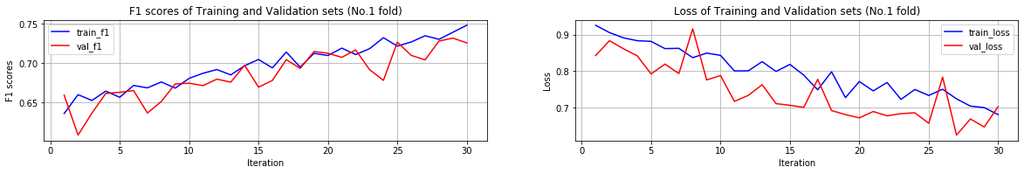

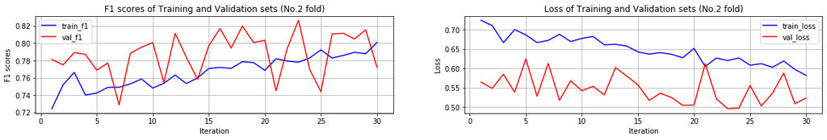

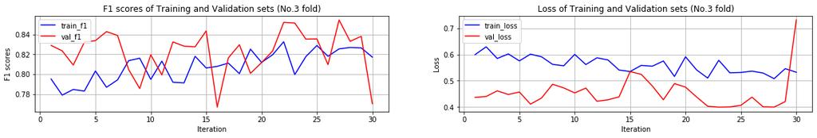

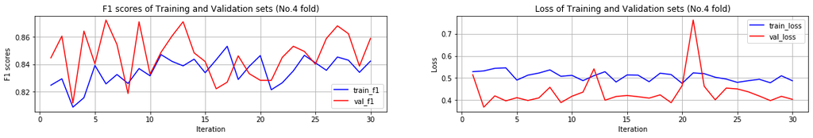

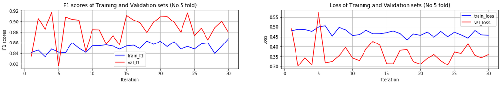

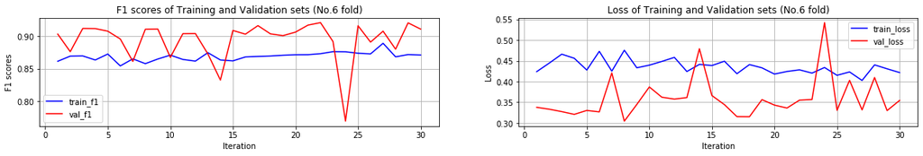

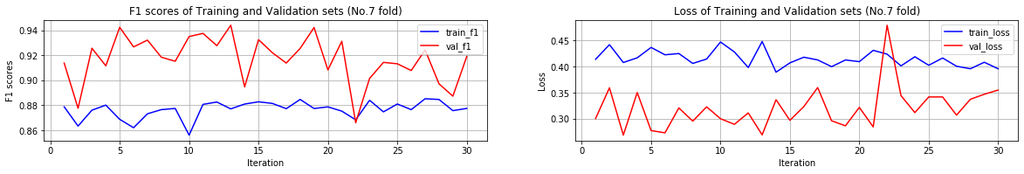

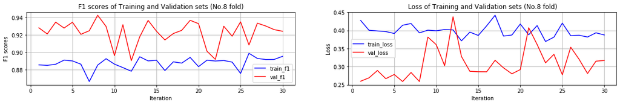

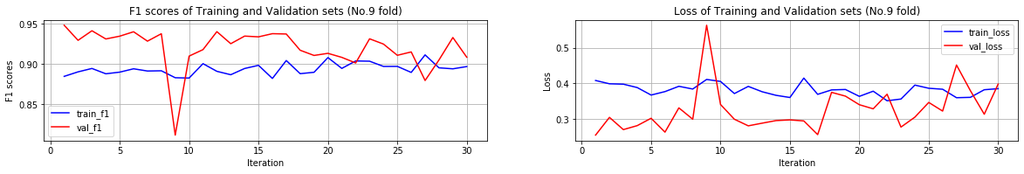

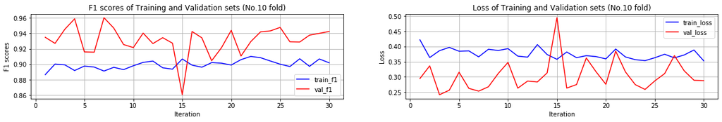

```python
# there are 10 folds, so there are 10 groups of data
for i in range(0, len(cv_training_f1_score)):
    iteration = range(1,len(cv_training_f1_score[i])+1)
    plt.figure(figsize=(20,30))
    plt.subplot(10,2,1)
    plt.plot(iteration, cv_training_f1_score[i], linestyle='-', color='blue', label='train_f1')
    plt.plot(iteration, cv_val_f1_score[i], linestyle='-', color='red', label='val_f1')
    plt.grid()
    plt.legend()
    plt.xlabel('Iteration')
    plt.ylabel('F1 scores')
    plt.title('F1 scores of Training and Validation sets (No.%.0f fold)' % (i+1))

    plt.subplot(10,2,2)
    plt.plot(iteration, cv_training_loss[i], linestyle='-', color='blue', label='train_loss')
    plt.plot(iteration, cv_val_loss[i], linestyle='-', color='red', label='val_loss')
    plt.grid()
    plt.legend()
    plt.xlabel('Iteration')
    plt.ylabel('Loss')
    plt.title('Loss of Training and Validation sets (No.%.0f fold)' % (i+1))
```

## ResNet

Conv64->maxpool->Conv32->maxpool->Conv64*2->Conv32,split->maxpool->Dense256, the kernel is 3X3

```python
%%time
l2_lambda = 0.0001
# now lets use the LeNet architecture with batch norm
# We will also use ReLU where approriate and drop out
from keras.layers.normalization import BatchNormalization
from keras.layers import Add
from keras.layers import average, concatenate
from keras.models import Input, Model

input_holder = Input(shape=(img_wh, img_wh, 1))

# start with a conv layer
x = Conv2D(filters=64, # change the number of filters
               input_shape = (img_wh,img_wh,1),
               kernel_size=(3,3),
               kernel_initializer='he_uniform',
               kernel_regularizer=l2(l2_lambda),
               padding='same',
               activation='relu',
               data_format="channels_last")(input_holder)

x = MaxPooling2D(pool_size=(2, 2), data_format="channels_last")(x)

x = Conv2D(filters=32,
               kernel_size=(3,3),
               kernel_initializer='he_uniform',
               kernel_regularizer=l2(l2_lambda),
               padding='same',
               activation='relu',
               data_format="channels_last")(x)

x_split = MaxPooling2D(pool_size=(2, 2), data_format="channels_last")(x)

x = Conv2D(filters=64,
               kernel_size=(1,1),
               kernel_initializer='he_uniform',
               kernel_regularizer=l2(l2_lambda),
               padding='same',
               activation='relu',
               data_format="channels_last")(x_split)

x = Conv2D(filters=64,
               kernel_size=(3,3),
               kernel_initializer='he_uniform',
               kernel_regularizer=l2(l2_lambda),
               padding='same',
               activation='relu',
               data_format="channels_last")(x)

x = Conv2D(filters=32,
               kernel_size=(1,1),
               kernel_initializer='he_uniform',
               kernel_regularizer=l2(l2_lambda),
               padding='same',
               activation='relu',
               data_format="channels_last")(x)

# now add back in the split layer, x_split (residual added in)
x = Add()([x, x_split])
x = Activation("relu")(x)

x = MaxPooling2D(pool_size=(2, 2), data_format="channels_last")(x)

x = Flatten()(x)
x = Dropout(0.25)(x)
x = Dense(256)(x)
x = Activation("relu")(x)
x = Dropout(0.5)(x)
x = Dense(NUM_CLASSES)(x)
x = Activation('softmax')(x)

resnet = Model(inputs=input_holder,outputs=x)

resnet.summary()
```

```
Model: "model_2"
__________________________________________________________________________________________________
Layer (type)                    Output Shape         Param #     Connected to
==================================================================================================
input_3 (InputLayer)            (None, 78, 78, 1)    0
__________________________________________________________________________________________________
conv2d_20 (Conv2D)              (None, 78, 78, 64)   640         input_3[0][0]
__________________________________________________________________________________________________
max_pooling2d_9 (MaxPooling2D)  (None, 39, 39, 64)   0           conv2d_20[0][0]
__________________________________________________________________________________________________
conv2d_21 (Conv2D)              (None, 39, 39, 32)   18464       max_pooling2d_9[0][0]
__________________________________________________________________________________________________
max_pooling2d_10 (MaxPooling2D) (None, 19, 19, 32)   0           conv2d_21[0][0]
__________________________________________________________________________________________________
conv2d_22 (Conv2D)              (None, 19, 19, 64)   2112        max_pooling2d_10[0][0]
__________________________________________________________________________________________________
conv2d_23 (Conv2D)              (None, 19, 19, 64)   36928       conv2d_22[0][0]
__________________________________________________________________________________________________
conv2d_24 (Conv2D)              (None, 19, 19, 32)   2080        conv2d_23[0][0]
__________________________________________________________________________________________________
add_2 (Add)                     (None, 19, 19, 32)   0           conv2d_24[0][0]
                                                                 max_pooling2d_10[0][0]
__________________________________________________________________________________________________
activation_4 (Activation)       (None, 19, 19, 32)   0           add_2[0][0]
__________________________________________________________________________________________________
max_pooling2d_11 (MaxPooling2D) (None, 9, 9, 32)     0           activation_4[0][0]
__________________________________________________________________________________________________
flatten_5 (Flatten)             (None, 2592)         0           max_pooling2d_11[0][0]
__________________________________________________________________________________________________
dropout_9 (Dropout)             (None, 2592)         0           flatten_5[0][0]
__________________________________________________________________________________________________
dense_9 (Dense)                 (None, 256)          663808      dropout_9[0][0]
__________________________________________________________________________________________________
activation_5 (Activation)       (None, 256)          0           dense_9[0][0]
__________________________________________________________________________________________________
dropout_10 (Dropout)            (None, 256)          0           activation_5[0][0]
__________________________________________________________________________________________________
dense_10 (Dense)                (None, 6)            1542        dropout_10[0][0]
__________________________________________________________________________________________________
activation_6 (Activation)       (None, 6)            0           dense_10[0][0]
==================================================================================================
Total params: 725,574
Trainable params: 725,574
Non-trainable params: 0
__________________________________________________________________________________________________
Wall time: 163 ms
```

```python
resnet.compile(loss='categorical_crossentropy', # 'categorical_crossentropy' 'mean_squared_error'
                optimizer='adam', # 'adadelta' 'rmsprop'
                metrics=[f1])
```

```python
from matplotlib import pyplot as plt

n_folds = 10
skf = StratifiedKFold(n_splits=n_folds)

cv_training_f1_score = []
cv_training_loss = []

cv_val_f1_score = []
cv_val_loss = []


iternum = 1
for train_indices, val_indices in skf.split(X_train, y_train):
    X_tmp_train = X_train[train_indices]
    y_tmp_train = y_train_ohe[train_indices]

    X_tmp_val = X_train[val_indices]
    y_tmp_val = y_train_ohe[val_indices]

    history = resnet.fit_generator(datagen.flow(X_tmp_train, y_tmp_train, batch_size=128),
                                   steps_per_epoch=int(len(X_tmp_train)/128), # how many generators to go through per epoch
                                   epochs=30, verbose=0,
                                    validation_data=(X_tmp_val,y_tmp_val))
    # save the performance data of different training and validation set

    cv_training_f1_score.append(history.history.get('f1'))
    cv_val_f1_score.append(history.history.get('val_f1'))

    cv_training_loss.append(history.history.get('loss'))
    cv_val_loss.append(history.history.get('val_loss'))
```

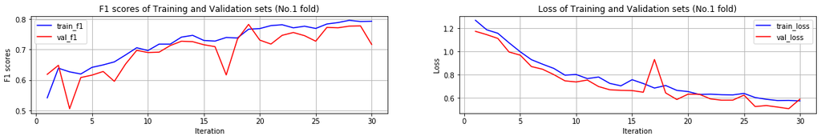

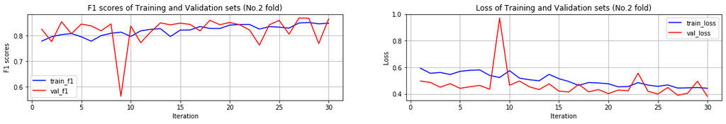

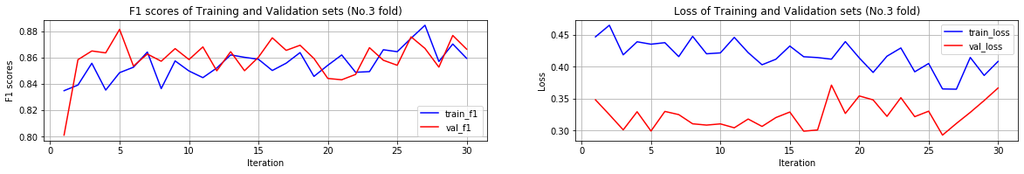

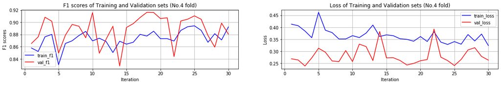

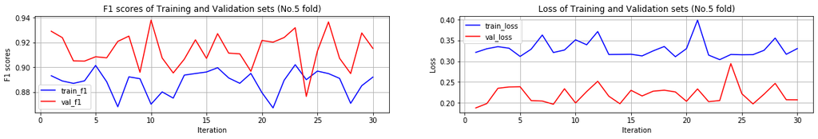

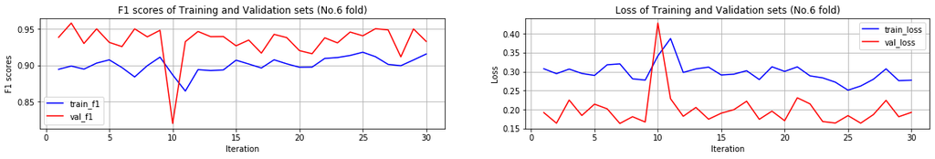

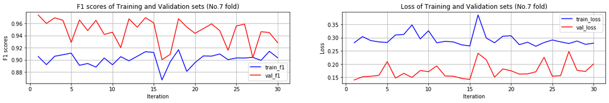

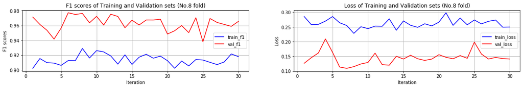

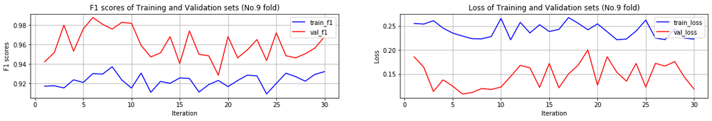

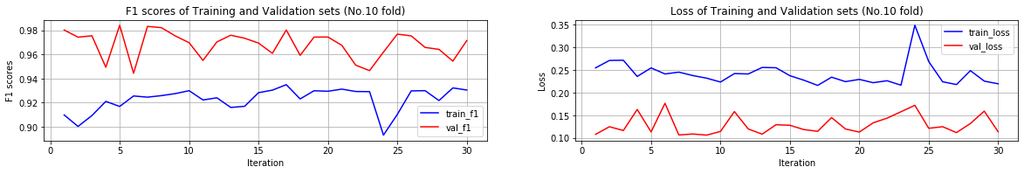

```python
# there are 10 folds, so there are 10 groups of data
for i in range(0, len(cv_training_f1_score)):
    iteration = range(1,len(cv_training_f1_score[i])+1)
    plt.figure(figsize=(20,30))
    plt.subplot(10,2,1)
    plt.plot(iteration, cv_training_f1_score[i], linestyle='-', color='blue', label='train_f1')
    plt.plot(iteration, cv_val_f1_score[i], linestyle='-', color='red', label='val_f1')
    plt.grid()
    plt.legend()
    plt.xlabel('Iteration')
    plt.ylabel('F1 scores')
    plt.title('F1 scores of Training and Validation sets (No.%.0f fold)' % (i+1))

    plt.subplot(10,2,2)
    plt.plot(iteration, cv_training_loss[i], linestyle='-', color='blue', label='train_loss')
    plt.plot(iteration, cv_val_loss[i], linestyle='-', color='red', label='val_loss')
    plt.grid()
    plt.legend()
    plt.xlabel('Iteration')
    plt.ylabel('Loss')
    plt.title('Loss of Training and Validation sets (No.%.0f fold)' % (i+1))
```

## Resnet modify

Conv64->maxpool->Conv32->maxpool->Conv64*2->Conv32,split->maxpool->Dense256. we change the kernel to 5X5

```python
%%time

x = Conv2D(filters=64, # change the number of filters
               input_shape = (img_wh,img_wh,1),
               kernel_size=(5,5),
               kernel_initializer='he_uniform',
               kernel_regularizer=l2(l2_lambda),
               padding='same',
               activation='relu',
               data_format="channels_last")(input_holder)

x = MaxPooling2D(pool_size=(2, 2), data_format="channels_last")(x)

x = Conv2D(filters=32,
               kernel_size=(3,3),
               kernel_initializer='he_uniform',
               kernel_regularizer=l2(l2_lambda),
               padding='same',
               activation='relu',
               data_format="channels_last")(x)

x_split = MaxPooling2D(pool_size=(2, 2), data_format="channels_last")(x)

x = Conv2D(filters=64,
               kernel_size=(1,1),
               kernel_initializer='he_uniform',
               kernel_regularizer=l2(l2_lambda),
               padding='same',
               activation='relu',
               data_format="channels_last")(x_split)

x = Conv2D(filters=64,
               kernel_size=(3,3),
               kernel_initializer='he_uniform',
               kernel_regularizer=l2(l2_lambda),
               padding='same',
               activation='relu',
               data_format="channels_last")(x)

x = Conv2D(filters=32,
               kernel_size=(1,1),
               kernel_initializer='he_uniform',
               kernel_regularizer=l2(l2_lambda),
               padding='same',
               activation='relu',
               data_format="channels_last")(x)

# now add back in the split layer, x_split (residual added in)
x = Add()([x, x_split])
x = Activation("relu")(x)

x = MaxPooling2D(pool_size=(2, 2), data_format="channels_last")(x)

x = Flatten()(x)
x = Dropout(0.25)(x)
x = Dense(256)(x)
x = Activation("relu")(x)
x = Dropout(0.5)(x)
x = Dense(NUM_CLASSES)(x)
x = Activation('softmax')(x)

resnet_modify = Model(inputs=input_holder,outputs=x)

resnet_modify.summary()
```

```
Model: "model_2"
__________________________________________________________________________________________________
Layer (type)                    Output Shape         Param #     Connected to
==================================================================================================
input_1 (InputLayer)            (None, 78, 78, 1)    0
__________________________________________________________________________________________________
conv2d_14 (Conv2D)              (None, 78, 78, 64)   1664        input_1[0][0]
__________________________________________________________________________________________________
max_pooling2d_7 (MaxPooling2D)  (None, 39, 39, 64)   0           conv2d_14[0][0]
__________________________________________________________________________________________________
conv2d_15 (Conv2D)              (None, 39, 39, 32)   18464       max_pooling2d_7[0][0]
__________________________________________________________________________________________________
max_pooling2d_8 (MaxPooling2D)  (None, 19, 19, 32)   0           conv2d_15[0][0]
__________________________________________________________________________________________________
conv2d_16 (Conv2D)              (None, 19, 19, 64)   2112        max_pooling2d_8[0][0]
__________________________________________________________________________________________________
conv2d_17 (Conv2D)              (None, 19, 19, 64)   36928       conv2d_16[0][0]
__________________________________________________________________________________________________
conv2d_18 (Conv2D)              (None, 19, 19, 32)   2080        conv2d_17[0][0]
__________________________________________________________________________________________________
add_2 (Add)                     (None, 19, 19, 32)   0           conv2d_18[0][0]
                                                                 max_pooling2d_8[0][0]
__________________________________________________________________________________________________
activation_4 (Activation)       (None, 19, 19, 32)   0           add_2[0][0]
__________________________________________________________________________________________________
max_pooling2d_9 (MaxPooling2D)  (None, 9, 9, 32)     0           activation_4[0][0]
__________________________________________________________________________________________________
flatten_4 (Flatten)             (None, 2592)         0           max_pooling2d_9[0][0]
__________________________________________________________________________________________________
dropout_7 (Dropout)             (None, 2592)         0           flatten_4[0][0]
__________________________________________________________________________________________________
dense_7 (Dense)                 (None, 256)          663808      dropout_7[0][0]
__________________________________________________________________________________________________
activation_5 (Activation)       (None, 256)          0           dense_7[0][0]
__________________________________________________________________________________________________
dropout_8 (Dropout)             (None, 256)          0           activation_5[0][0]
__________________________________________________________________________________________________
dense_8 (Dense)                 (None, 6)            1542        dropout_8[0][0]
__________________________________________________________________________________________________
activation_6 (Activation)       (None, 6)            0           dense_8[0][0]
==================================================================================================
Total params: 726,598
Trainable params: 726,598
Non-trainable params: 0
__________________________________________________________________________________________________
Wall time: 163 ms
```

```python
resnet_modify.compile(loss='categorical_crossentropy', # 'categorical_crossentropy' 'mean_squared_error'
                optimizer='adam', # 'adadelta' 'rmsprop'
                metrics=[f1])
```

```python
from matplotlib import pyplot as plt

n_folds = 10
skf = StratifiedKFold(n_splits=n_folds)

cv_training_f1_score = []
cv_training_loss = []

cv_val_f1_score = []
cv_val_loss = []


iternum = 1
for train_indices, val_indices in skf.split(X_train, y_train):
    X_tmp_train = X_train[train_indices]
    y_tmp_train = y_train_ohe[train_indices]

    X_tmp_val = X_train[val_indices]
    y_tmp_val = y_train_ohe[val_indices]

    history = resnet_modify.fit_generator(datagen.flow(X_tmp_train, y_tmp_train, batch_size=128),
                                   steps_per_epoch=int(len(X_tmp_train)/128), # how many generators to go through per epoch
                                   epochs=30, verbose=0,
                                    validation_data=(X_tmp_val,y_tmp_val))
    # save the performance data of different training and validation set

    cv_training_f1_score.append(history.history.get('f1'))
    cv_val_f1_score.append(history.history.get('val_f1'))

    cv_training_loss.append(history.history.get('loss'))
    cv_val_loss.append(history.history.get('val_loss'))
```

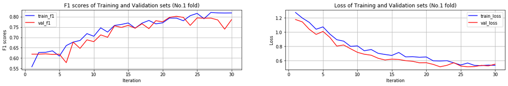

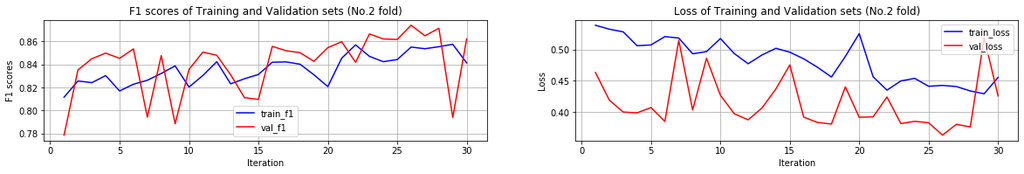

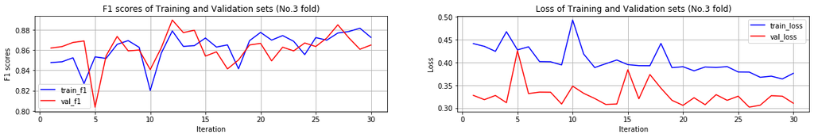

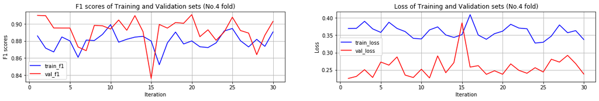

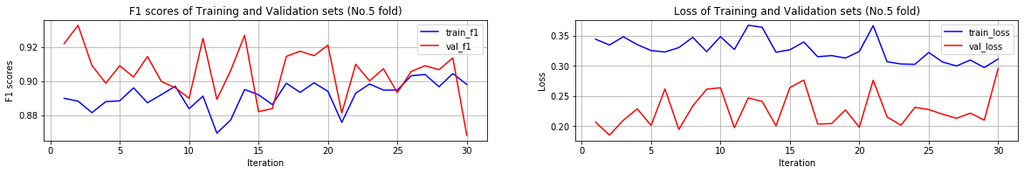

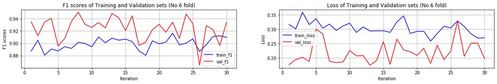

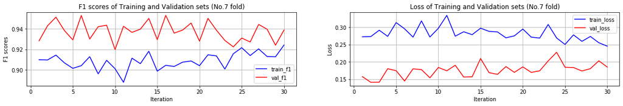

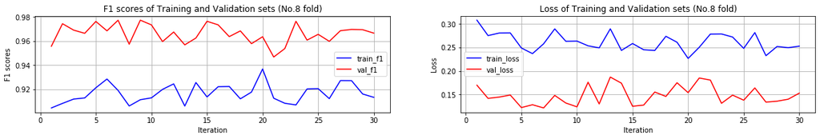

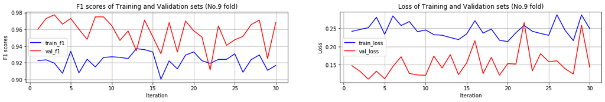

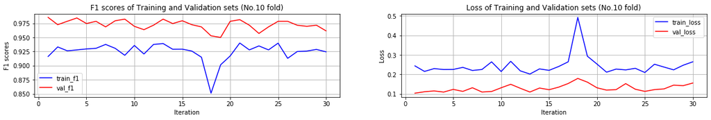

```python
# there are 10 folds, so there are 10 groups of data
for i in range(0, len(cv_training_f1_score)):
    iteration = range(1,len(cv_training_f1_score[i])+1)
    plt.figure(figsize=(20,30))
    plt.subplot(10,2,1)
    plt.plot(iteration, cv_training_f1_score[i], linestyle='-', color='blue', label='train_f1')
    plt.plot(iteration, cv_val_f1_score[i], linestyle='-', color='red', label='val_f1')
    plt.grid()
    plt.legend()
    plt.xlabel('Iteration')
    plt.ylabel('F1 scores')
    plt.title('F1 scores of Training and Validation sets (No.%.0f fold)' % (i+1))

    plt.subplot(10,2,2)
    plt.plot(iteration, cv_training_loss[i], linestyle='-', color='blue', label='train_loss')
    plt.plot(iteration, cv_val_loss[i], linestyle='-', color='red', label='val_loss')
    plt.grid()
    plt.legend()
    plt.xlabel('Iteration')
    plt.ylabel('Loss')
    plt.title('Loss of Training and Validation sets (No.%.0f fold)' % (i+1))
```

### Xception style architecture

```python
# Xception style architecture
from keras.layers import SeparableConv2D
from keras.layers.normalization import BatchNormalization
from keras.layers import Add
from keras.layers import average, concatenate
from keras.models import Input, Model

l2_lambda = 0.000001



input_holder = Input(shape=(img_wh, img_wh, 1))

# start with a conv layer
x = Conv2D(filters=64, # change the number of filters
               input_shape = (img_wh,img_wh,1),
               kernel_size=(3,3),
               kernel_initializer='he_uniform',
               kernel_regularizer=l2(l2_lambda),
               padding='same',
               activation='relu',
               data_format="channels_last")(input_holder)

x = MaxPooling2D(pool_size=(2, 2), data_format="channels_last")(x)

x = Conv2D(filters=32,
               kernel_size=(3,3),
               kernel_initializer='he_uniform',
               kernel_regularizer=l2(l2_lambda),
               padding='same',
               activation='relu',
               data_format="channels_last")(x)


x_split = MaxPooling2D(pool_size=(2, 2), data_format="channels_last")(x)

x = SeparableConv2D(filters=32,
               input_shape = (img_wh,img_wh,1),
               kernel_size=(3,3),
               kernel_initializer='he_uniform',
               kernel_regularizer=l2(l2_lambda),
               padding='same',
               activation='relu',
               depth_multiplier = 1, # controls output channels
               data_format="channels_last")(x_split)


x_split = Add()([x, x_split])

x = SeparableConv2D(filters=32,
               input_shape = (img_wh,img_wh,1),
               kernel_size=(3,3),
               kernel_initializer='he_uniform',
               kernel_regularizer=l2(l2_lambda),
               padding='same',
               activation='relu',
               depth_multiplier = 1, # controls output channels
               data_format="channels_last")(x_split)


x_split = Add()([x, x_split])


x = Activation("relu")(x_split)

x = MaxPooling2D(pool_size=(2, 2), data_format="channels_last")(x)

x = Flatten()(x)
x = Dropout(0.25)(x)
x = Dense(256, activation="relu")(x)
x = Dropout(0.5)(x)
x = Dense(NUM_CLASSES,activation="softmax")(x)

xception_model = Model(inputs=input_holder,outputs=x)

xception_model.summary()
```

```
Model: "model_3"
__________________________________________________________________________________________________
Layer (type)                    Output Shape         Param #     Connected to
==================================================================================================
input_2 (InputLayer)            (None, 78, 78, 1)    0
__________________________________________________________________________________________________
conv2d_19 (Conv2D)              (None, 78, 78, 64)   640         input_2[0][0]
__________________________________________________________________________________________________
max_pooling2d_10 (MaxPooling2D) (None, 39, 39, 64)   0           conv2d_19[0][0]
__________________________________________________________________________________________________
conv2d_20 (Conv2D)              (None, 39, 39, 32)   18464       max_pooling2d_10[0][0]
__________________________________________________________________________________________________
max_pooling2d_11 (MaxPooling2D) (None, 19, 19, 32)   0           conv2d_20[0][0]
__________________________________________________________________________________________________
separable_conv2d_1 (SeparableCo (None, 19, 19, 32)   1344        max_pooling2d_11[0][0]
__________________________________________________________________________________________________
add_3 (Add)                     (None, 19, 19, 32)   0           separable_conv2d_1[0][0]
                                                                 max_pooling2d_11[0][0]
__________________________________________________________________________________________________
separable_conv2d_2 (SeparableCo (None, 19, 19, 32)   1344        add_3[0][0]
__________________________________________________________________________________________________
add_4 (Add)                     (None, 19, 19, 32)   0           separable_conv2d_2[0][0]
                                                                 add_3[0][0]
__________________________________________________________________________________________________
activation_7 (Activation)       (None, 19, 19, 32)   0           add_4[0][0]
__________________________________________________________________________________________________
max_pooling2d_12 (MaxPooling2D) (None, 9, 9, 32)     0           activation_7[0][0]
__________________________________________________________________________________________________
flatten_5 (Flatten)             (None, 2592)         0           max_pooling2d_12[0][0]
__________________________________________________________________________________________________
dropout_9 (Dropout)             (None, 2592)         0           flatten_5[0][0]
__________________________________________________________________________________________________
dense_9 (Dense)                 (None, 256)          663808      dropout_9[0][0]
__________________________________________________________________________________________________
dropout_10 (Dropout)            (None, 256)          0           dense_9[0][0]
__________________________________________________________________________________________________
dense_10 (Dense)                (None, 6)            1542        dropout_10[0][0]
==================================================================================================
Total params: 687,142
Trainable params: 687,142
Non-trainable params: 0
__________________________________________________________________________________________________
```

```python
# speed up by training by not using augmentation, perhaps there are faster ways??
xception_model.compile(loss='categorical_crossentropy', # 'categorical_crossentropy' 'mean_squared_error'
                optimizer='adam', # 'adadelta' 'rmsprop'
                metrics=[f1])
```

```python
from sklearn.model_selection import StratifiedKFold
from sklearn.metrics import f1_score
```

```python
from matplotlib import pyplot as plt

n_folds = 10
skf = StratifiedKFold(n_splits=n_folds)

cv_training_f1_score = []
cv_training_loss = []

cv_val_f1_score = []
cv_val_loss = []


iternum = 1
for train_indices, val_indices in skf.split(X_train, y_train):
    X_tmp_train = X_train[train_indices]
    y_tmp_train = y_train_ohe[train_indices]

    X_tmp_val = X_train[val_indices]
    y_tmp_val = y_train_ohe[val_indices]

    history = xception_model.fit_generator(datagen.flow(X_tmp_train, y_tmp_train, batch_size=128),
                   steps_per_epoch=int(len(X_tmp_train)/128), # how many generators to go through per epoch
                   epochs=30, verbose=0,
                   validation_data=(X_tmp_val,y_tmp_val)
                  )
    # save the performance data of different training and validation set

    cv_training_f1_score.append(history.history.get('f1'))
    cv_val_f1_score.append(history.history.get('val_f1'))

    cv_training_loss.append(history.history.get('loss'))
    cv_val_loss.append(history.history.get('val_loss'))
```

[output not shown]